# Tipología y ciclo de vida de los datos - Práctica 2

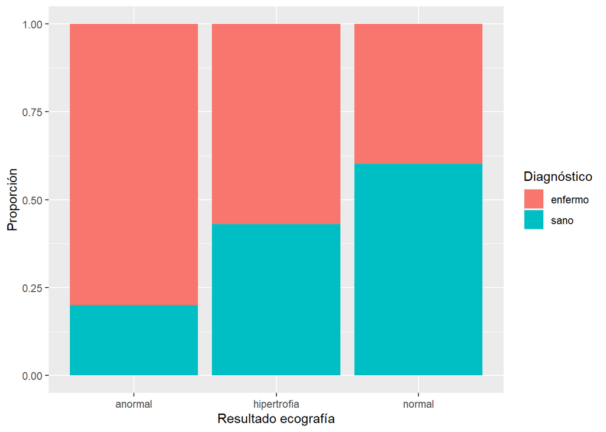

```r
ggplot(datos,aes(x=ecografia,fill=diagnostico)) +geom_bar(position="fill") + xlab("Resultado ecografía") + ylab("Proporción") + scale_fill_discrete(name="Diagnóstico")
```

Variable *ejercicio* (angina inducida por el ejercicio físico).

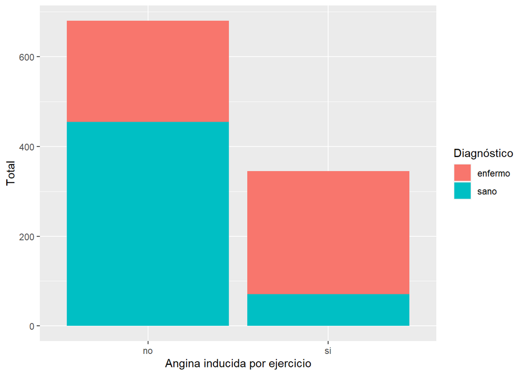

```r
ggplot(datos,aes(x=ejercicio,fill=diagnostico)) +geom_bar() + xlab("Angina inducida por ejercicio") + ylab("Total") + scale_fill_discrete(name="Diagnóstico")
```

En proporción.

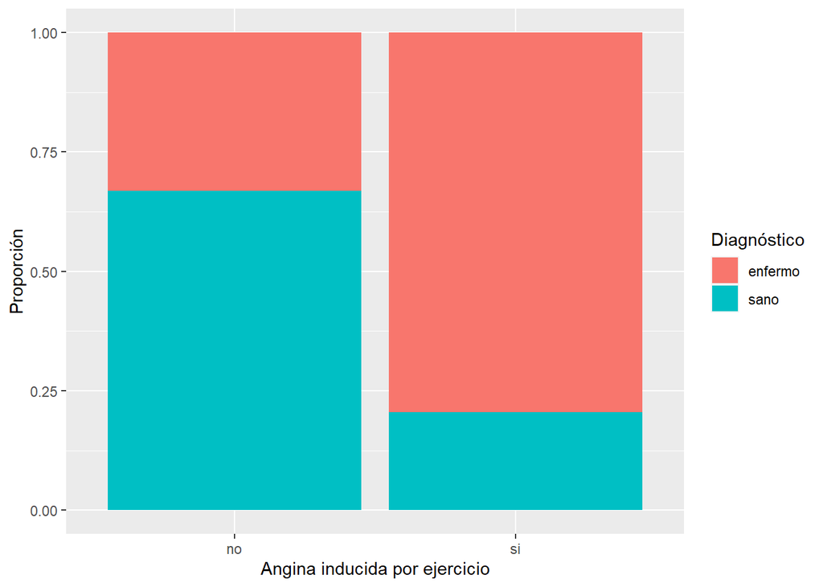

```r
ggplot(datos,aes(x=ejercicio,fill=diagnostico)) +geom_bar(position="fill") + xlab("Angina inducida por ejercicio") + ylab("Proporción") + scale_fill_discrete(name="Diagnóstico")
```

Variable *pendiente* (pendiente del segmento ST del electrocardiograma en el pico de ejercicio).

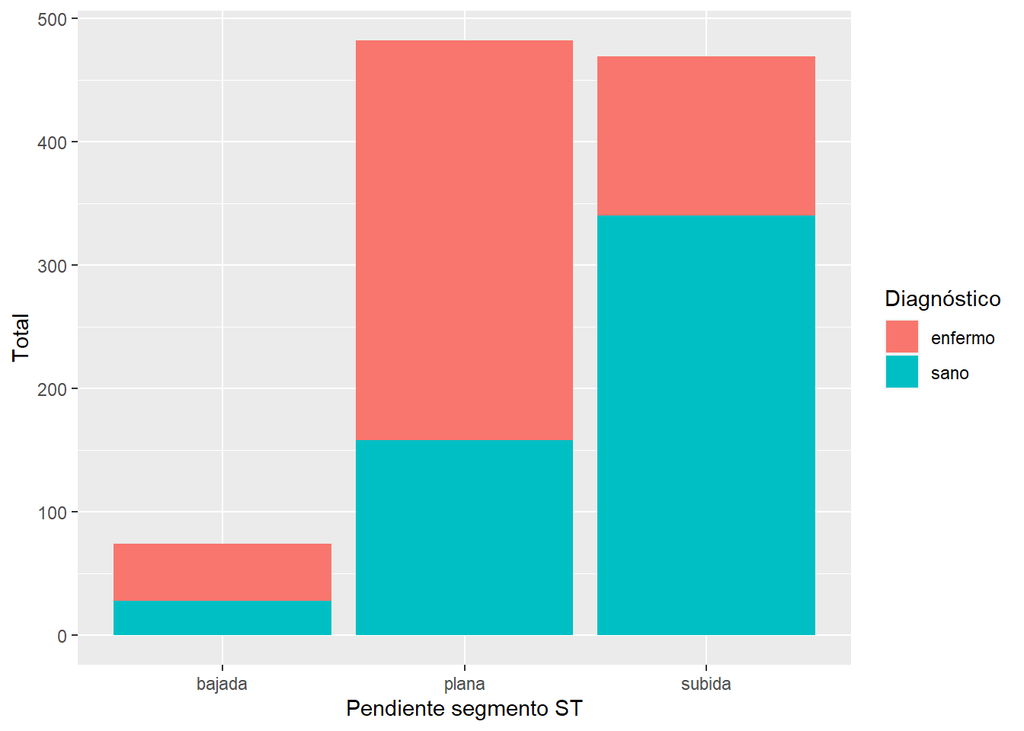

```r
ggplot(datos,aes(x=pendiente,fill=diagnostico)) +geom_bar() + xlab("Pendiente segmento ST") + ylab("Total") + scale_fill_discrete(name="Diagnóstico")
```

En proporción.

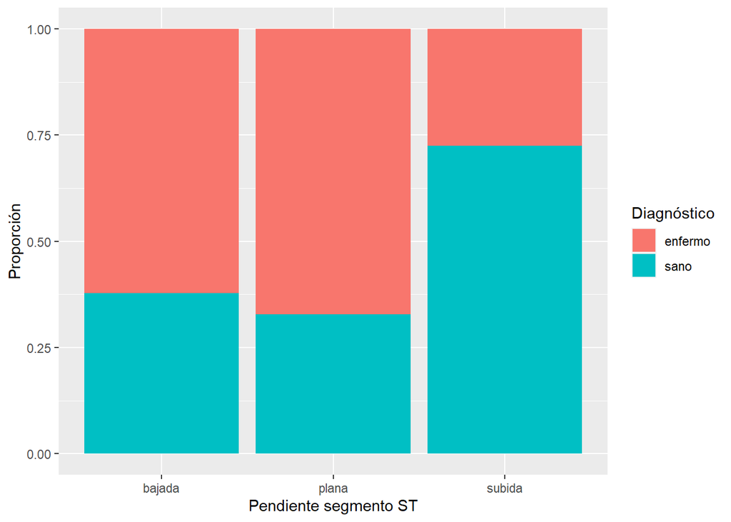

```r
ggplot(datos,aes(x=pendiente,fill=diagnostico)) +geom_bar(position="fill") + xlab("Pendiente segmento ST") + ylab("Proporción") + scale_fill_discrete(name="Diagnóstico")
```

Variable *vasos.coloreados* (número de vasos sanguíneos principales coloreados en la fluoroscopia).

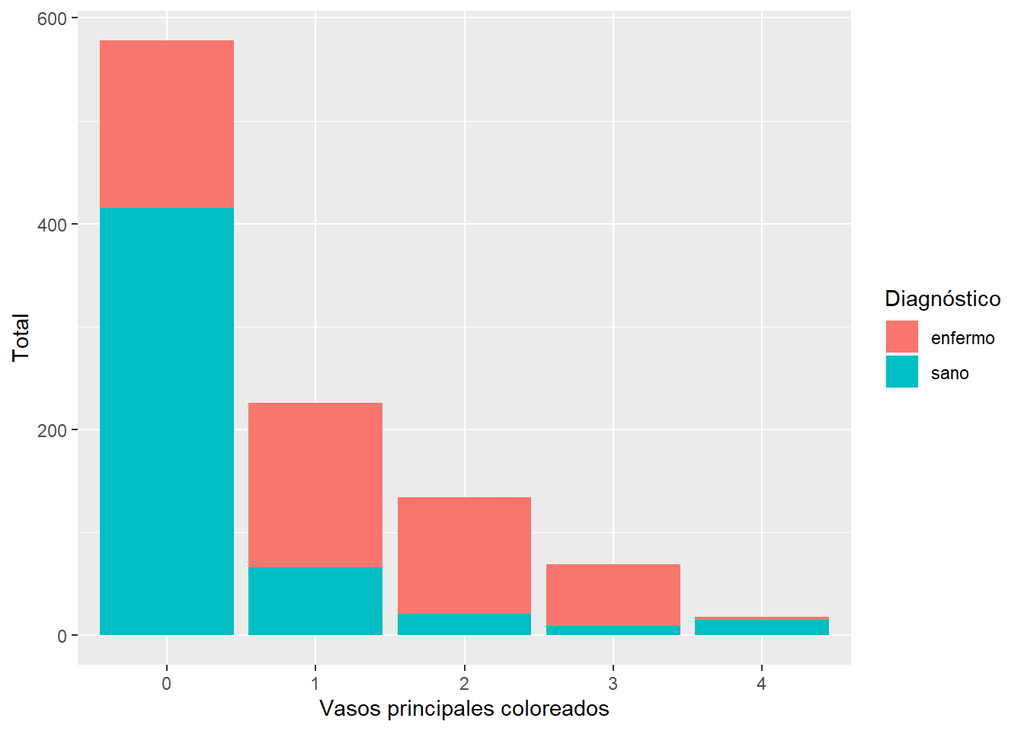

```r
ggplot(datos,aes(x=vasos.coloreados,fill=diagnostico)) +geom_bar() + xlab("Vasos principales coloreados") + ylab("Total") + scale_fill_discrete(name="Diagnóstico")
```

En proporción.

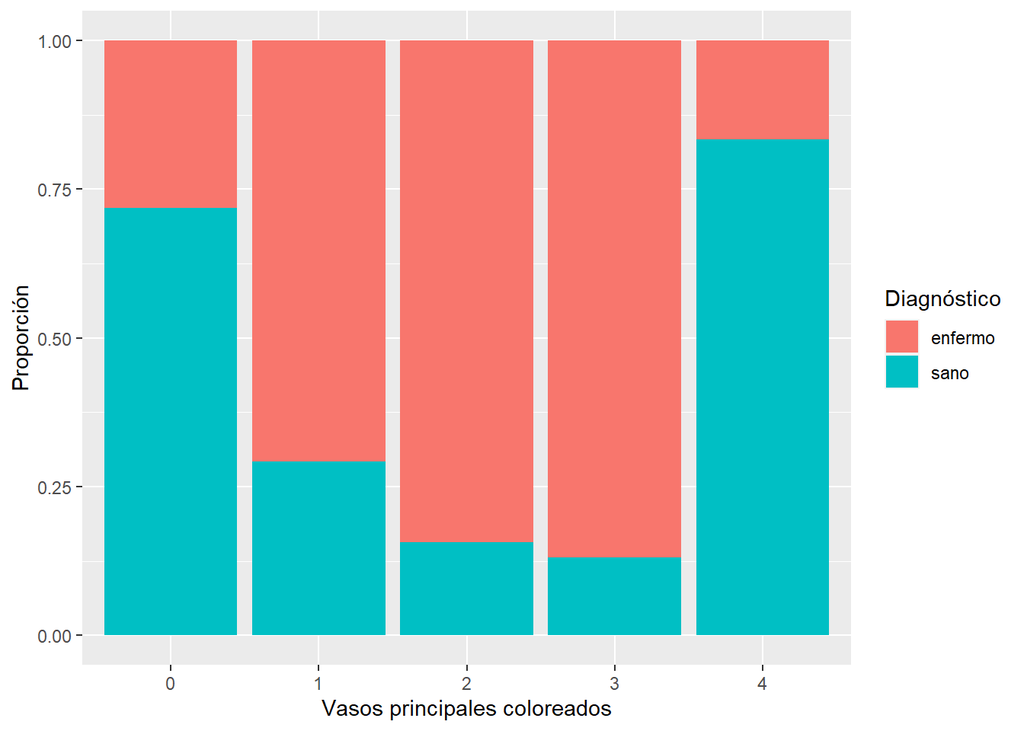

```r
ggplot(datos,aes(x=vasos.coloreados,fill=diagnostico)) +geom_bar(position="fill") + xlab("Vasos principales coloreados") + ylab("Proporción") + scale_fill_discrete(name="Diagnóstico")
```

Variable *exploracion.talio* (resultado de la prueba de esfuerzo con talio).

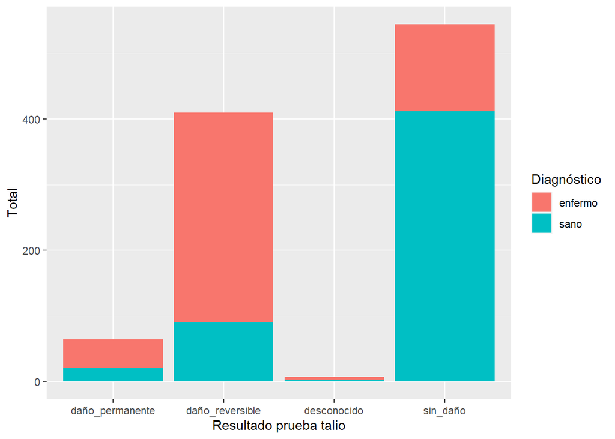

```r
ggplot(datos,aes(x=exploracion.talio,fill=diagnostico)) +geom_bar() + xlab("Resultado prueba talio") + ylab("Total") + scale_fill_discrete(name="Diagnóstico")
```

En proporción.

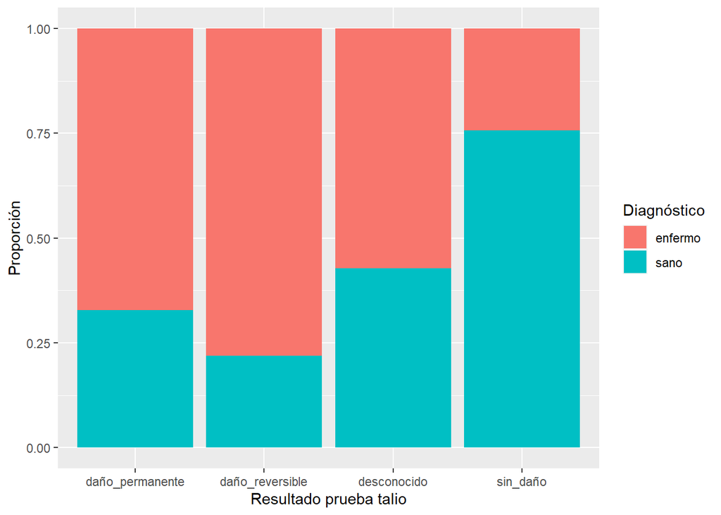

```r
ggplot(datos,aes(x=exploracion.talio,fill=diagnostico)) +geom_bar(position="fill") + xlab("Resultado prueba talio") + ylab("Proporción") + scale_fill_discrete(name="Diagnóstico")
```

Vamos a generar con los datos un modelo de **regresión logística** para poder predecir el valor de la variable diagnóstico. La regresión logística nos proporciona una estimación de probabilidad para la predicción.

En una primera aproximación utilizaremos todas las variables disponibles para generar el modelo y luego eliminaremos aquellas que no sean significativas para el resultado.

```r
modelo.diagnostico.todas <- glm(datos$diagnostico ~ datos$edad + datos$sexo + datos$dolor + datos$tension + datos$colesterol + datos$azucar + datos$ecografia + datos$frecmax + datos$ejercicio + datos$depST + datos$pendiente + datos$vasos.coloreados + datos$exploracion.talio , data = datos, family = "binomial")
summary(modelo.diagnostico.todas)
```

```
##
## Call:
## glm(formula = datos$diagnostico ~ datos$edad + datos$sexo + datos$dolor +
##     datos$tension + datos$colesterol + datos$azucar + datos$ecografia +
##     datos$frecmax + datos$ejercicio + datos$depST + datos$pendiente +
##     datos$vasos.coloreados + datos$exploracion.talio, family = "binomial",
##     data = datos)
##
## Deviance Residuals:
##     Min       1Q   Median       3Q      Max
## -2.8582  -0.2917   0.0718   0.4167   3.1908
##
## Coefficients:
##                                         Estimate Std. Error z value Pr(>|z|)
## (Intercept)                            -0.077851   2.171147  -0.036 0.971396
## datos$edad                              0.026846   0.013950   1.924 0.054297
## datos$sexomujer                         1.992347   0.314204   6.341 2.28e-10
## datos$doloratipico                      0.886380   0.308803   2.870 0.004100
## datos$dolorotro                         2.006394   0.286281   7.008 2.41e-12
## datos$dolortipico                       2.409722   0.391965   6.148 7.86e-10
## datos$tension                          -0.024979   0.006537  -3.821 0.000133
## datos$colesterol                       -0.005462   0.002307  -2.367 0.017914
## datos$azucarsi                          0.380096   0.319620   1.189 0.234356
## datos$ecografiahipertrofia              0.800417   1.536998   0.521 0.602530
## datos$ecografianormal                   1.197685   1.538426   0.779 0.436267
## datos$frecmax                           0.021692   0.006525   3.324 0.000886
## datos$ejerciciosi                      -0.750331   0.248746  -3.016 0.002557
## datos$depST                            -0.403411   0.132156  -3.053 0.002269
## datos$pendienteplana                   -0.595618   0.472076  -1.262 0.207057
## datos$pendientesubida                   0.799689   0.504500   1.585 0.112941
## datos$vasos.coloreados1                -2.334076   0.286781  -8.139 3.99e-16
## datos$vasos.coloreados2                -3.597039   0.444870  -8.086 6.19e-16
## datos$vasos.coloreados3                -2.288131   0.532138  -4.300 1.71e-05
## datos$vasos.coloreados4                 1.565677   0.930256   1.683 0.092363
## datos$exploracion.taliodaño_reversible -1.805570   0.435590  -4.145 3.40e-05
## datos$exploracion.taliodesconocido     -2.796813   1.466219  -1.908 0.056456
## datos$exploracion.taliosin_daño        -0.392167   0.441819  -0.888 0.374745
##
## (Intercept)
## datos$edad                             .
```

[output cut: 16 more lines]

```
## datos$vasos.coloreados3                ***
## datos$vasos.coloreados4                .
## datos$exploracion.taliodaño_reversible ***
## datos$exploracion.taliodesconocido     .
## datos$exploracion.taliosin_daño
## ---
## Signif. codes:  0 '***' 0.001 '**' 0.01 '*' 0.05 '.' 0.1 ' ' 1
##
## (Dispersion parameter for binomial family taken to be 1)
##
##     Null deviance: 1420.24  on 1024  degrees of freedom
## Residual deviance:  606.82  on 1002  degrees of freedom
## AIC: 652.82
##
## Number of Fisher Scoring iterations: 6
```

La función *glm* nos ha generado las variables auxiliares para cada uno de los valores de las variables categóricas. El nivel base de referencia que usa R por defecto es el primer nivel de la variable de tipo factor e interpreta el resto de niveles en base a este nivel.

Estudiamos la bondad del ajuste del modelo que hemos obtenido con el test de Hosman-Lemeshow. En la librería (ResourceSelection) hay una función que ajusta el test de Hosmer- Lemeshow.

En el test de Hosman-Lemeshow la hipótesis nula es que los valores observados corresponden con los valores esperados.  
Realizamos el test al modelo.

```r
hl <- hoslem.test(modelo.diagnostico.todas$y, fitted(modelo.diagnostico.todas))
hl
```

```
##
##  Hosmer and Lemeshow goodness of fit (GOF) test
##
## data:  modelo.diagnostico.todas$y, fitted(modelo.diagnostico.todas)
## X-squared = 83.157, df = 8, p-value = 1.132e-14
```

Obtenemos un valor p < 0.05, que es significativo, con lo que podemos rechazar la hipótesis nula de que los valores esperados se corresponden a los valores predichos por el modelo de regresión logística.

Podemos visualizar las diferencias entre los valores esperados y los obtenidos por el modelo.

```r
expected <- round(hl$expected, 0)
observed <- round(hl$observed, 0)
cbind(expected, observed)
```

```
##                    yhat0 yhat1  y0  y1
## [0.000447,0.00615]   104     0 101   3
## (0.00615,0.0245]     102     1 103   0
## (0.0245,0.113]        98     6 101   3
## (0.113,0.291]         80    19  81  18
## (0.291,0.587]         55    49  56  48
## (0.587,0.744]         32    69  39  62
## (0.744,0.883]         18    84   3  99
## (0.883,0.96]           7    98   3 102
## (0.96,0.983]           3    98  12  89
## (0.983,0.999]          1   101   0 102
```

```r
difer<-abs(expected - observed)
colSums(difer)
```

```
## yhat0 yhat1
##    45    45
```

Si dibujamos la curva ROC.

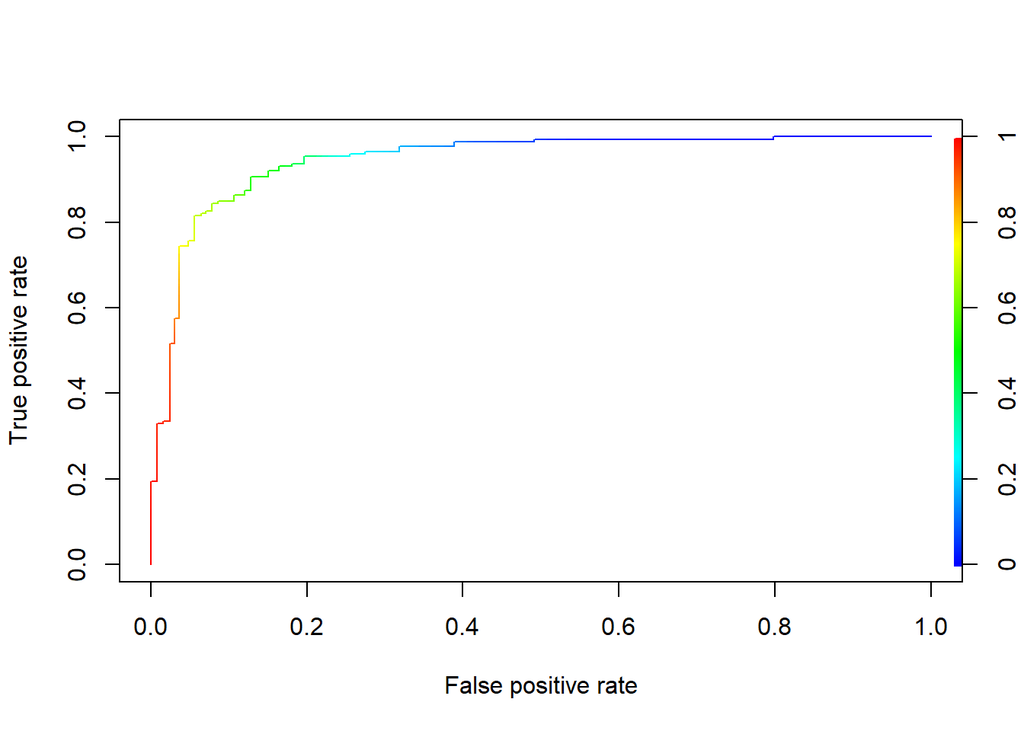

```r
predicciones <- predict(modelo.diagnostico.todas, type = "response")
pred <- prediction(predicciones, datos$diagnostico)
perf <- performance(pred,"tpr","fpr")
plot(perf,colorize=TRUE)
```

El área bajo la curva es.

```r
as.numeric(performance(pred,"auc")@y.values)
```

```
## [1] 0.9464823
```

La precisión del modelo es bastante alta, un 0.94, significa que hay un 94% de posibilidades de que el modelo pueda distinguir entre un paciente sano y otro enfermo.

**Reducción del modelo**:

Si revisamos los coeficientes del modelo vemos que solo algunos de ellos tienen valores p significativos, podemos suponer que solo éstos realizan una contribución significativa a la predicción del resultado.

El resto los eliminamos del modelo, quedando de la siguiente forma.

```r
modelo.diagnostico <- glm(datos$diagnostico ~ datos$sexo + datos$dolor + datos$tension + datos$colesterol + datos$frecmax + datos$ejercicio + datos$depST  + datos$vasos.coloreados + datos$exploracion.talio , data = datos, family = "binomial")
summary(modelo.diagnostico)
```

```
##
## Call:
## glm(formula = datos$diagnostico ~ datos$sexo + datos$dolor +
##     datos$tension + datos$colesterol + datos$frecmax + datos$ejercicio +
##     datos$depST + datos$vasos.coloreados + datos$exploracion.talio,
##     family = "binomial", data = datos)
##
## Deviance Residuals:
##      Min        1Q    Median        3Q       Max
## -2.64187  -0.35085   0.09337   0.46325   3.03373
##
## Coefficients:
##                                         Estimate Std. Error z value Pr(>|z|)
## (Intercept)                             1.586900   1.200317   1.322 0.186146
## datos$sexomujer                         1.741367   0.291945   5.965 2.45e-09
## datos$doloratipico                      1.047683   0.301023   3.480 0.000501
## datos$dolorotro                         1.940095   0.270072   7.184 6.79e-13
## datos$dolortipico                       2.087828   0.361097   5.782 7.39e-09
## datos$tension                          -0.020645   0.005863  -3.521 0.000430
## datos$colesterol                       -0.006044   0.002116  -2.856 0.004294
## datos$frecmax                           0.025213   0.005738   4.394 1.11e-05
## datos$ejerciciosi                      -0.792451   0.242190  -3.272 0.001068
## datos$depST                            -0.627303   0.117716  -5.329 9.88e-08
## datos$vasos.coloreados1                -2.010009   0.260309  -7.722 1.15e-14
## datos$vasos.coloreados2                -2.775652   0.373075  -7.440 1.01e-13
## datos$vasos.coloreados3                -1.960216   0.498543  -3.932 8.43e-05
## datos$vasos.coloreados4                 0.841112   0.853752   0.985 0.324528
## datos$exploracion.taliodaño_reversible -1.665954   0.423497  -3.934 8.36e-05
## datos$exploracion.taliodesconocido     -2.385804   1.253438  -1.903 0.056987
## datos$exploracion.taliosin_daño        -0.202342   0.428766  -0.472 0.636986
##
## (Intercept)
## datos$sexomujer                        ***
## datos$doloratipico                     ***
## datos$dolorotro                        ***
## datos$dolortipico                      ***
## datos$tension                          ***
## datos$colesterol                       **
## datos$frecmax                          ***
## datos$ejerciciosi                      **
## datos$depST                            ***
## datos$vasos.coloreados1                ***
## datos$vasos.coloreados2                ***
## datos$vasos.coloreados3                ***
## datos$vasos.coloreados4
## datos$exploracion.taliodaño_reversible ***
## datos$exploracion.taliodesconocido     .
## datos$exploracion.taliosin_daño
## ---
## Signif. codes:  0 '***' 0.001 '**' 0.01 '*' 0.05 '.' 0.1 ' ' 1
##
## (Dispersion parameter for binomial family taken to be 1)
##
##     Null deviance: 1420.24  on 1024  degrees of freedom
## Residual deviance:  642.69  on 1008  degrees of freedom
## AIC: 676.69
##
## Number of Fisher Scoring iterations: 6
```

Calulamos los OR del modelo.

```r
exp(modelo.diagnostico$coefficients)
```

```
##                            (Intercept)                        datos$sexomujer
##                             4.88856982                             5.70513628
##                     datos$doloratipico                        datos$dolorotro
##                             2.85103662                             6.95941109
##                      datos$dolortipico                          datos$tension
##                             8.06737147                             0.97956667
##                       datos$colesterol                          datos$frecmax
##                             0.99397446                             1.02553364
##                      datos$ejerciciosi                            datos$depST
##                             0.45273382                             0.53403009
##                datos$vasos.coloreados1                datos$vasos.coloreados2
##                             0.13398748                             0.06230884
##                datos$vasos.coloreados3                datos$vasos.coloreados4
##                             0.14082800                             2.31894403
## datos$exploracion.taliodaño_reversible     datos$exploracion.taliodesconocido
##                             0.18901024                             0.09201495
##        datos$exploracion.taliosin_daño
##                             0.81681538
```

Si el valor es mayor que 1, entonces indica que a medida que aumenta el predictor, las probabilidades de los resultados aumentan. A la inversa, un valor menor que 1 indica que a medida que aumenta el predictor, las probabilidades de los resultados disminuyen.

En base a los coeficientes obtenidos, podemos decir que el ser mujer influye de manera positiva en el modelo, aumentando la probabilidad de que el pacientes esté sano, respecto a que esté enfermo.

En este caso, podemos decir que las probabilidades de que un paciente esté sano si es mujer son 5.7 veces superiores a las de un paciente varón.

Evaluamos al igual que antes la bondad del modelo reducido.

```r
hl <- hoslem.test(modelo.diagnostico$y, fitted(modelo.diagnostico))
hl
```

```
##
##  Hosmer and Lemeshow goodness of fit (GOF) test
##
## data:  modelo.diagnostico$y, fitted(modelo.diagnostico)
## X-squared = 5.2479, df = 8, p-value = 0.7308
```

En este caso, obtenemos un valor p > 0.05, que no es significativo, con lo que no podemos rechazar la hipótesis nula y por lo tanto podemos afirmar que los valores esperados se corresponden a los valores predichos por el modelo de regresión logística.

Comparamos los valores esperados con los observados.

```r
expected <- round(hl$expected, 0)
observed <- round(hl$observed, 0)
cbind(expected, observed)
```

```
##                  yhat0 yhat1  y0  y1
## [0.00084,0.0087]   104     0 104   0
## (0.0087,0.0355]    101     2 100   3
## (0.0355,0.105]      94     7  92   9
## (0.105,0.304]       82    22  85  19
## (0.304,0.603]       56    48  58  46
## (0.603,0.742]       32    69  32  69
## (0.742,0.886]       17    84  13  88
## (0.886,0.943]        9    95  11  93
## (0.943,0.977]        4    97   4  97
## (0.977,0.998]        1   101   0 102
```

```r
difer<-abs(expected - observed)
colSums(difer)
```

```
## yhat0 yhat1
##    15    15
```

Comparando con el modelo anterior, se clasifican erróneamente 15 casos en lugar de 45.

Curva ROC

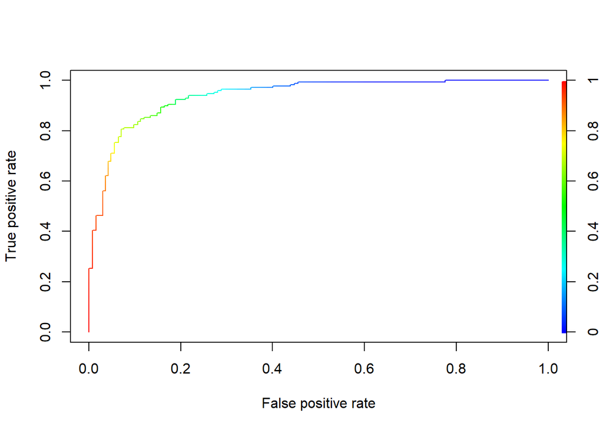

```r
predicciones <- predict(modelo.diagnostico, type = "response")
pred <- prediction(predicciones, datos$diagnostico)
perf <- performance(pred,"tpr","fpr")
plot(perf,colorize=TRUE)
```

El área bajo la curva es

```r
as.numeric(performance(pred,"auc")@y.values)
```

```
## [1] 0.9395521
```

Al eliminar las variables del modelo hemos perdido algo de precisión, pero prácticamente es la misma que con todas las variables.

## 5. Representación de los resultados a partir de tablas y gráficas.

A lo largo del desarrollo de la práctica se han ido mostrando las tablas y representaciones gráficas que ilustran cada caso.

## 6. Resolución del problema.

A partir de los resultados obtenidos, ¿cuáles son las conclusiones? ¿Los resultados permiten responder al problema?

La conclusión del estudio es que, como era de esperar, no todas las variables influyen de forma significativa en el diagnóstico del paciente como enfermo coronario o sano.

Hemos podido determinar que las variables que más influencia tienen sobre el resultado final son:

Si el número de vasos principales coloreados en la fluoroscopia está entre 1 y 3, el paciente tiene muchas posibilidades de estar enfermo.  
Si la exploración con talio muestra daño reversible también empeora considerablemente el pronóstico.

Nuestro objetivo era identificar los parámetros que nos permitan distinguir entre un paciente sano y enfermo, por lo que sí podríamos decir que hemos obtenido una respuesta al problema con el modelo de regresión.